# Lab 05- T-tests

# Chunk 1: Load libraries and datasets

1.1) Load `tidyverse` 1.2) read in two datasets “WormSperm.csv” and “BlackbirdTesto.csv” 1.3) What are the structures of each of these two datasets?

# Chunk 2: Define Hypotheses and Plot the data!

2.1) Using pipes, summarize the bird and sperm datasets so that you have a mean and standard error per group (treatment in birds and sex in sperm). 2.2) Identify a null and alternative hypotheses testing for differences in means in each of these datasets 2.3) Plot summarized data as a point plot with error bars representing the standard error

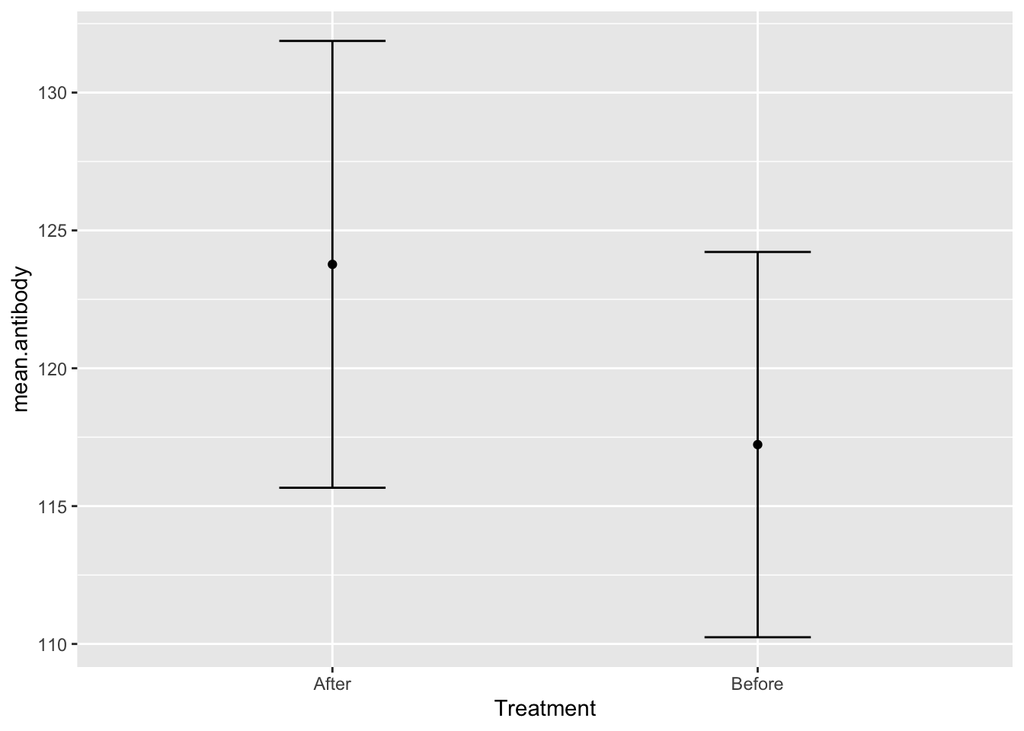

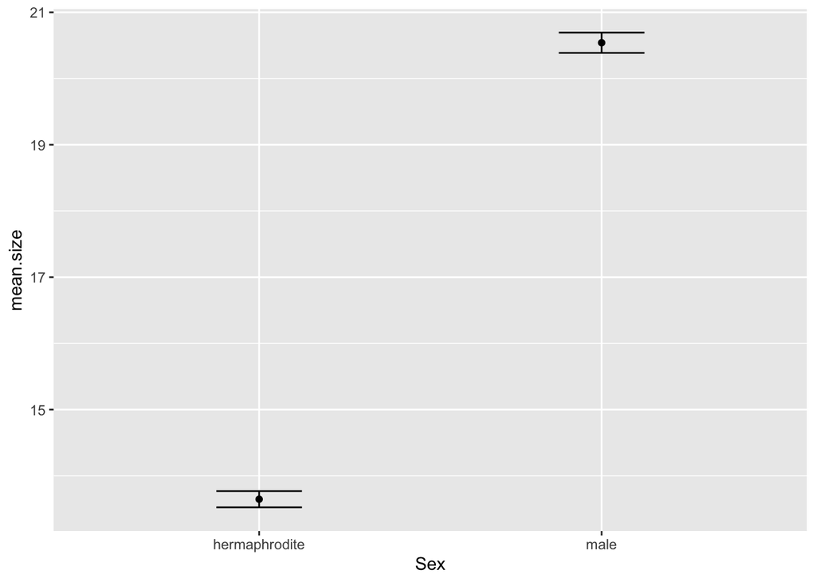

# Chunk 3: Check statistical assumptions

3.1) Using a shapiro test, a density plot and a qq plot check the two datasets for normality 3.1b) If any dataset is not normally distributed attempt a transformation to normalize the data. Does the transformation improve the normality of the distribution? 3.2) Using both a Levene Test and a Flinger-Kileen test, check if the datasets meet the assumption of homeogeneity of variances 3.3) What about the assumption of independence, are all observations in each of the datasets independent of each other?

```
##
##  Shapiro-Wilk normality test
##
## data:  bbirds$Antibody.production
## W = 0.91336, p-value = 0.0315
```

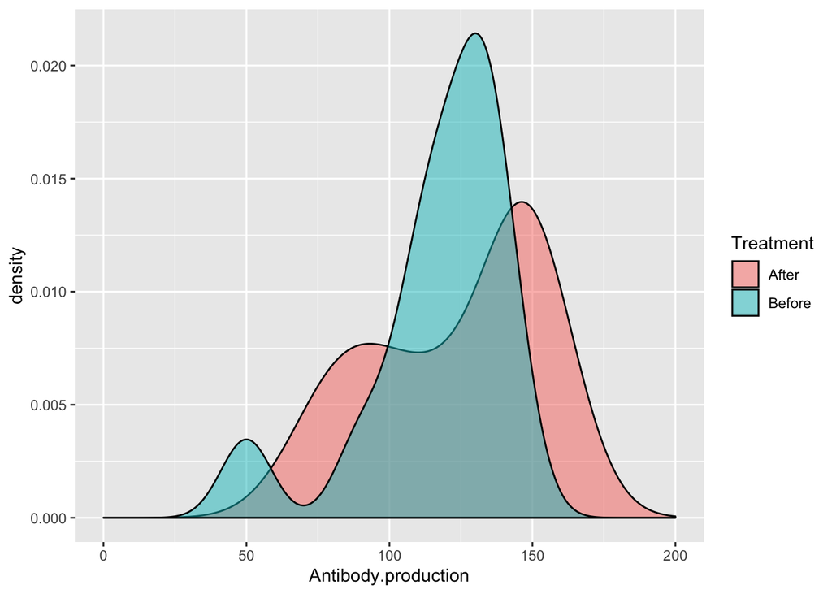

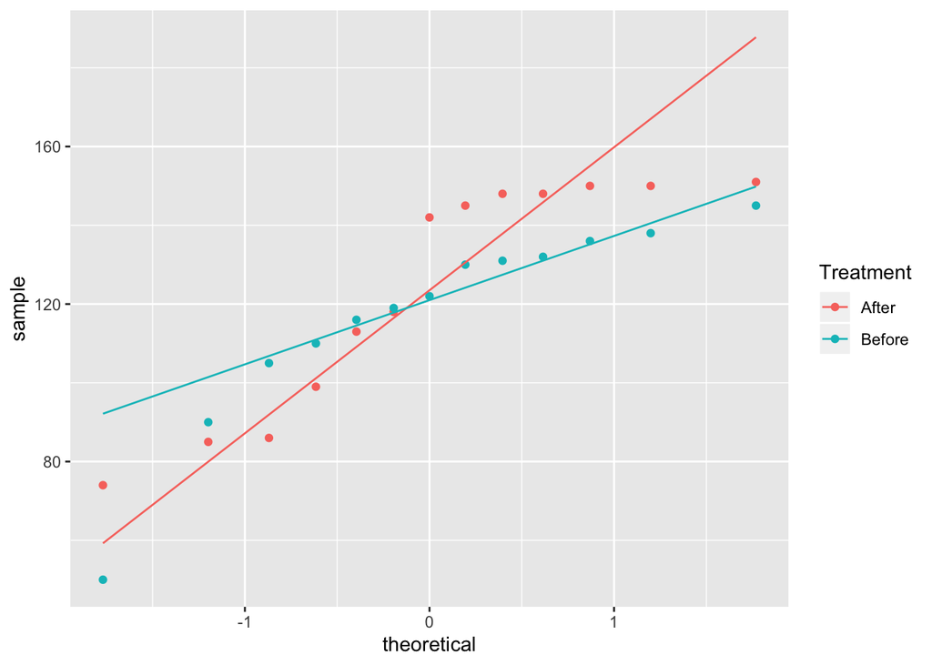

```
##
##  Shapiro-Wilk normality test
##
## data:  bbirds$Antibody.log
## W = 0.84557, p-value = 0.001169
```

```
##
##  Shapiro-Wilk normality test
##
## data:  sperm$SpermSize
## W = 0.95064, p-value < 2.2e-16
```

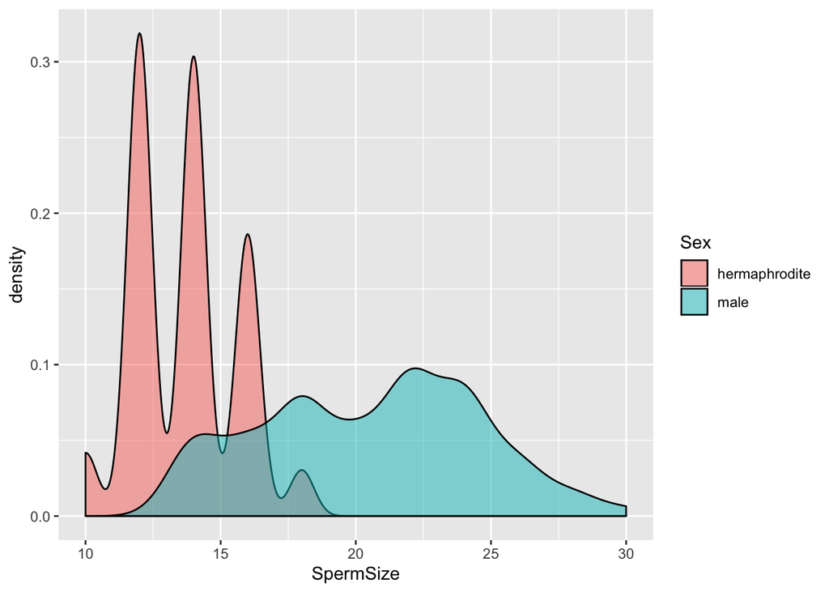

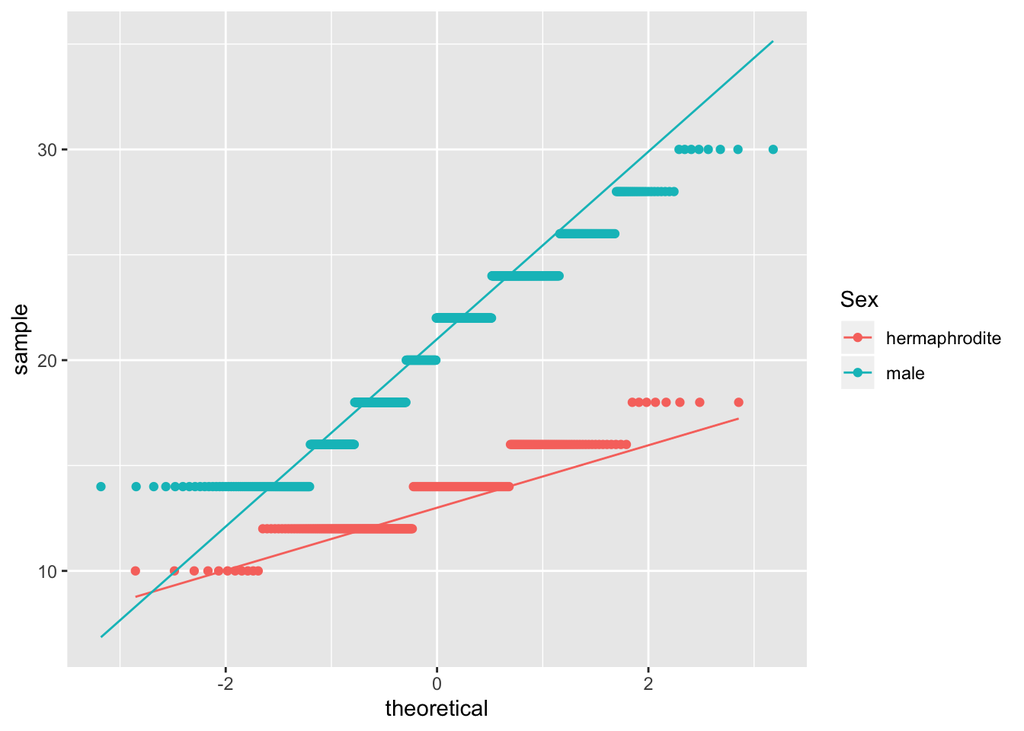

```
##
##  Shapiro-Wilk normality test
##
## data:  sperm$SpermSize
## W = 0.95064, p-value < 2.2e-16
```

```
## Levene's Test for Homogeneity of Variance (center = median)
##       Df F value Pr(>F)
## group  1  0.7604 0.3918
##       24
```

```
## Levene's Test for Homogeneity of Variance (center = median)
##        Df F value    Pr(>F)
## group   1  120.51 < 2.2e-16 ***
##       911
## ---
## Signif. codes:  0 '***' 0.001 '**' 0.01 '*' 0.05 '.' 0.1 ' ' 1
```

```
##
##  Fligner-Killeen test of homogeneity of variances
##
## data:  Antibody.production by Treatment
## Fligner-Killeen:med chi-squared = 0.1087, df = 1, p-value = 0.7416
```

```
##
##  Fligner-Killeen test of homogeneity of variances
##
## data:  SpermSize by Sex
## Fligner-Killeen:med chi-squared = 108.86, df = 1, p-value < 2.2e-16
```

# Chunk 4: Compelte an unpaired t-test

4.1) Complete a t.test for both the transformed and untranfromed Antibody production predicted by Treatment in the bbirds dataset. Set the `var.equal=TRUE`

4.2) Complete a t.test for both the transformed and untranfromed SpermSize predicted by Sex in the sperm dataset. Set the `var.equal=FALSE`

4.3) Interpret the results in your own words.

```
##
##  Two Sample t-test
##
## data:  Antibody.production by Treatment
## t = 0.61107, df = 24, p-value = 0.5469
## alternative hypothesis: true difference in means is not equal to 0
## 95 percent confidence interval:
##  -15.54536  28.62228
## sample estimates:
##  mean in group After mean in group Before
##             123.7692             117.2308
```

```
##
##  Two Sample t-test
##
## data:  Antibody.log by Treatment
## t = 0.52013, df = 24, p-value = 0.6077
## alternative hypothesis: true difference in means is not equal to 0
## 95 percent confidence interval:
##  -0.1631528  0.2730924
## sample estimates:
##  mean in group After mean in group Before
##             4.789215             4.734245
```

```
##
##  Welch Two Sample t-test
##
## data:  SpermSize by Sex
## t = -35.124, df = 828.43, p-value < 2.2e-16
## alternative hypothesis: true difference in means is not equal to 0
## 95 percent confidence interval:
##  -7.279072 -6.508588
## sample estimates:
## mean in group hermaphrodite          mean in group male
##                    13.64655                    20.54038
```

```
##
##  Welch Two Sample t-test
##
## data:  log.size by Sex
## t = -33.64, df = 587.07, p-value < 2.2e-16
## alternative hypothesis: true difference in means is not equal to 0
## 95 percent confidence interval:
##  -0.4217956 -0.3752614
## sample estimates:
## mean in group hermaphrodite          mean in group male
##                    2.604159                    3.002688
```

# Chunk 5: Complete a paired t-test and plot a paired point plot

5.1) Complete a paired t test for the bbirds dataset. use `paired=TRUE`

5.2) Interpret the results and discuss Why is this the appropriate test for these data?

5.3) Plot the data as paired point plot

```
##
##  Paired t-test
##
## data:  Antibody.log by Treatment
## t = 1.2435, df = 12, p-value = 0.2374
## alternative hypothesis: true difference in means is not equal to 0
## 95 percent confidence interval:
##  -0.04134676  0.15128638
## sample estimates:
## mean of the differences
##              0.05496981
```

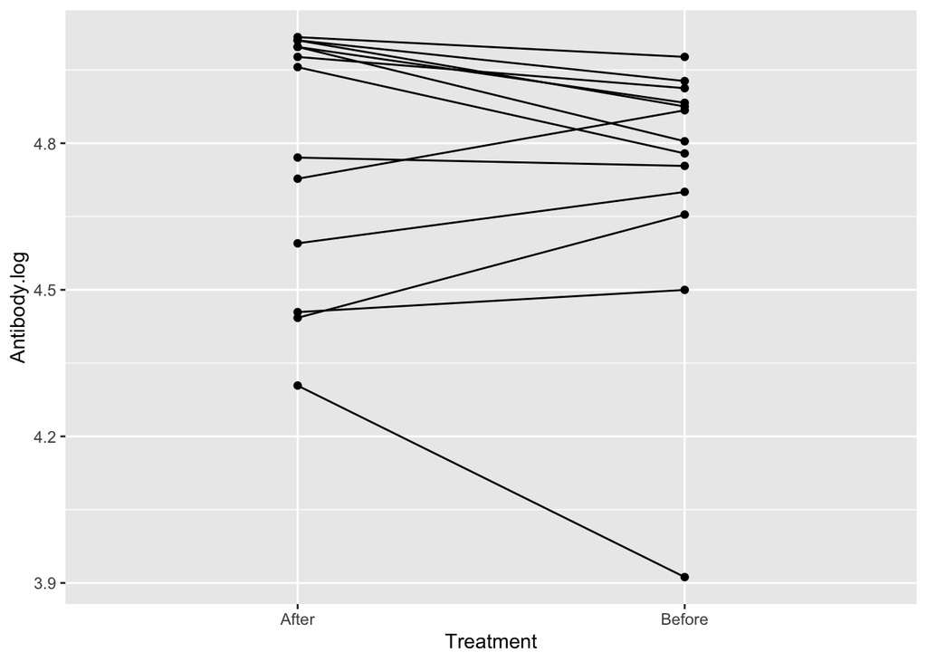

# Chunk 6: Non-parametric alternative

6.1) Complete a wilcoxon rank sums test of Antibody.log predicted by treatment with equal variances and paired data. Interpret the results in your own words.

6.2) Using the sperm data, complte a wilcoxon rank sums test of log.sperm size predicted by sex with unequal variances. Interpret the results in your own words.

```
##
##  Wilcoxon signed rank test
##
## data:  Antibody.log by Treatment
## V = 61, p-value = 0.3054
## alternative hypothesis: true location shift is not equal to 0
```

```
##
##  Wilcoxon rank sum test with continuity correction
##
## data:  log.size by Sex
## W = 10297, p-value < 2.2e-16
## alternative hypothesis: true location shift is not equal to 0
```